# Topo Data Visualization

Joey Hulbert

5/18/2022

# Purpose

The purpose of this markdown document is to list the steps we followed for visualization data with topo explanatory variables only.

# Data

The data used in the below models are described in the Data Wrangle folder.

## Response variables

**Note the below analysis uses the iNat data with 1510 observations. Amazing!**

- Response variables to consider
  - Number of unhealthy trees
  - Tree canopy symptoms

Below we visualizae data using canopy symptoms as the response variable

## Explanatory variables

- Explanatory variables included
  - Topo data
    - CTI - Climatic Moisture Index
    - SP - Slope Position
    - HLI - Heat Load Index
    - SDS - 2nd Derivitive slope
    - TRASP - Transformed Aspect - TRASP
    - IMI - Integrated Moisture Index
    - DEM - Elevation

# Data wrangling

There are multiple methods to group the response variables deepening on desired resolution or fineness of the model.

- Response grouping options
  - Original (no change)
  - Filtered Symptoms
    - We could drop trees outside of main symptom classes
      - Note loss of data outside of categories
  - Reclassified symptoms
    - Here we can created an ‘other’ variable to represent trees with the below symptoms
      - extra cone crop
      - yellowing canopy
    - We can also group trees with ‘old dead tops’ and ‘new dead tops’ into a ‘dead top’ category
  - Binary (healthy/unhealthy)

For now, we can move forward with the binary response grouping because it is the broadest and presumably the easiest for the model to classify with.

All tree health categories

```
## # A tibble: 12 × 2
## # Groups:   field.tree.canopy.symptoms [12]
##    field.tree.canopy.symptoms                             n
##    <fct>                                              <int>
##  1 Branch Dieback or 'Flagging'                          74
##  2 Browning Canopy                                       43
##  3 Candelabra top or very old spike top (old growth)      2
##  4 Extra Cone Crop                                        4
##  5 Healthy                                              813
##  6 Multiple Symptoms (please list in Notes)              31
##  7 New Dead Top (red or brown needles still attached)    48
##  8 Old Dead Top (needles already gone)                  154
##  9 Other (please describe in Notes)                      16
## 10 Thinning Canopy                                      225
## 11 Tree is dead                                          74
## 12 Yellowing Canopy                                      26
```

## Filter data

### Filter observatoins

We also want to filter observations to only those within Oregon and Washington as those are the only observations we extracted TOPO data for.

## Group response variables to binary values

Binary tree health categories

```
## # A tibble: 2 × 2
## # Groups:   field.tree.canopy.symptoms [2]
##   field.tree.canopy.symptoms     n
##   <fct>                      <int>
## 1 Healthy                      607
## 2 Unhealthy                    542
```

## Data Visualization

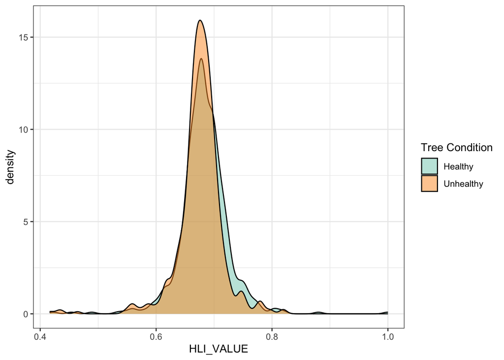

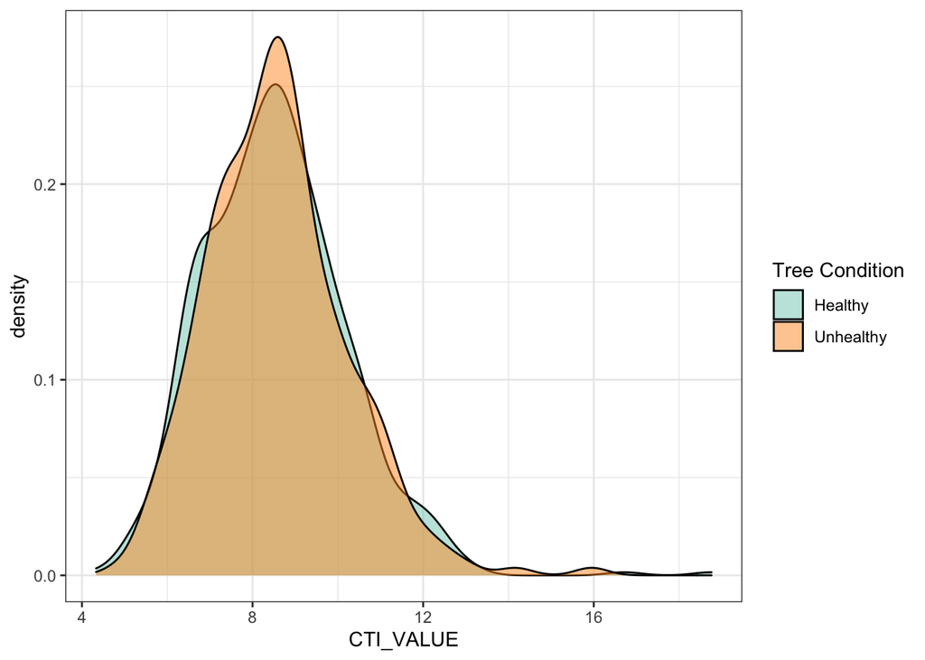

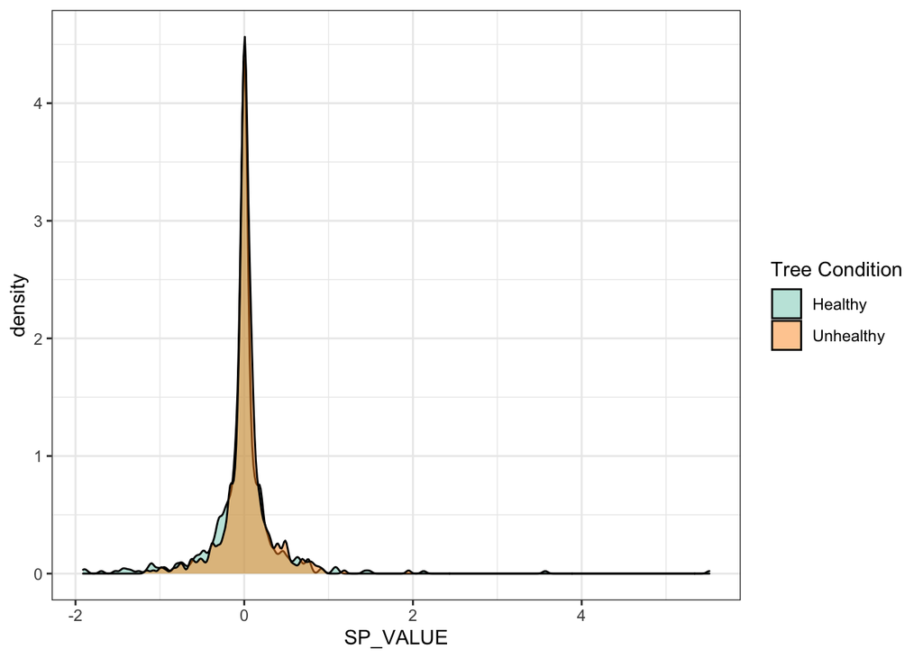

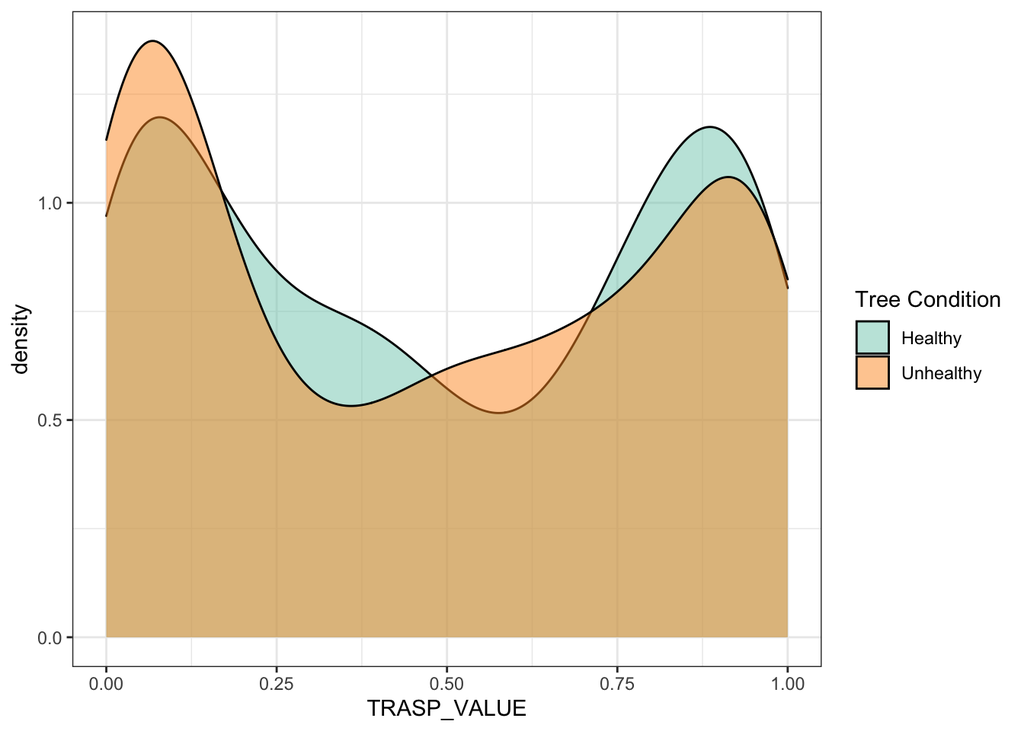

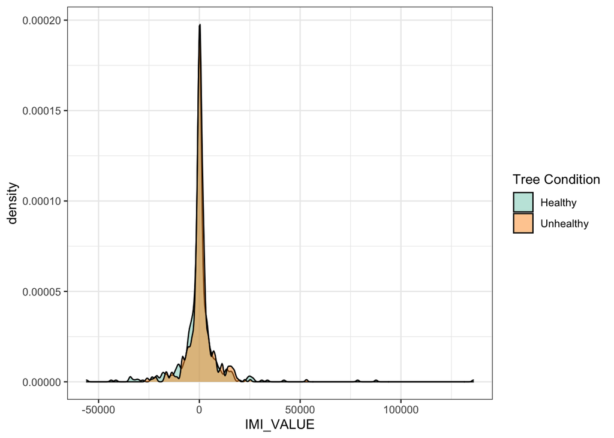

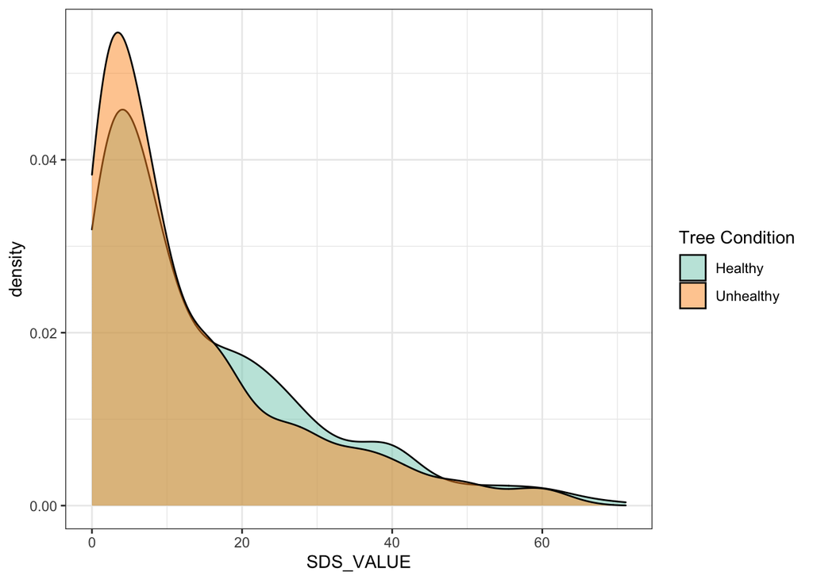

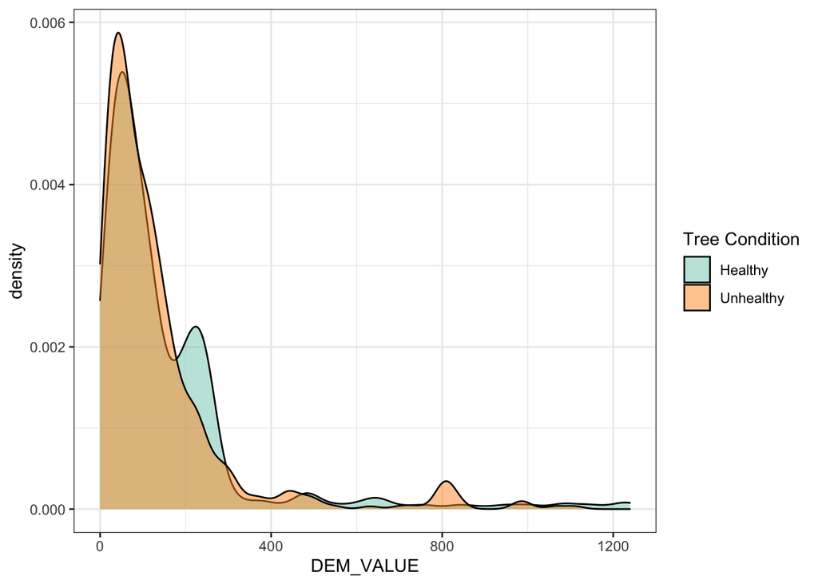